# Visualisting Data Integration with Anchorview

```r
library(anchorview)
library(Seurat)
library(tidyverse)
```

# Introduction

The technical nature of 10X library production is that different runs of the chromium system will generate data containing differences which are technical in nature and don’t derive from biological differences between samples.

When analysing data deriving from multiple libraries it is common to see that the different libraries separate in dimensionality reduction plots (PCA/tSNE/UMAP) such that cells from the same type do not cluster together, impeding the analysis of biological change in the samples.

In these circumstances it is usual to perform a data integration step to align the cells in different samples. This integration is driven by the identification of so-called “integration anchors” - pairs of cells from different datasets which are considered to be equivalent, and which would ideally sit on top of each other in a correctly integrated version of the data.

The integration of data within the Sueurat framework is often performed blindly, with the selection of anchors happening behind the scenes, and no review of the anchor points being performed before the data is transformed. Whilst this works well in many cases it can be beneficial to find a way to visualise the anchors in the data before actually running the transformation to see how numerous and consistent the identified anchors are. This is the purpose of the anchorview package.

Here we will step through an example data integration and show how the anchors can be visualised before the integration is performed.

# Loading data

The starting point for the analysis is a Seurat data object in which multiple samples have been loaded.

```r
SeuratData::InstallData("ifnb")
SeuratData::LoadData("ifnb") -> original_data
```

[output not shown]

```r
original_data
```

```
#> An object of class Seurat
#> 14053 features across 13999 samples within 1 assay
#> Active assay: RNA (14053 features, 0 variable features)
#>  2 layers present: counts, data
```

This is a dataset with two experiments in it, stimulated and unstimulated.

```r
original_data[[]] %>%
  group_by(stim) %>%
  count(name="Number_of_Cells")
```

```
#> # A tibble: 2 × 2
#> # Groups:   stim [2]
#>   stim  Number_of_Cells
#>   <chr>           <int>
#> 1 CTRL             6548
#> 2 STIM             7451
```

## Viewing unintegrated UMAP

Let’s do a simple processing of the data without integration to illustrate the problem we need to solve. We’re not optimising any of this but are just taking the common defaults.

```r
original_data %>%
  NormalizeData() %>%
  FindVariableFeatures() %>%
  ScaleData() %>%
  RunPCA() %>%
  RunUMAP(dims = 1:30, reduction = "pca", reduction.name = "umap") -> original_data
```

[output not shown]

Let’s look at the UMAP which resulted from this.

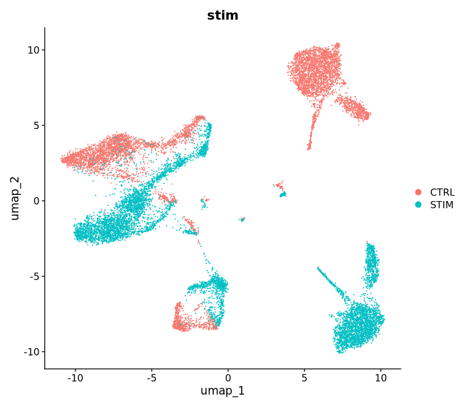

```r
DimPlot(original_data, group.by = "stim")
```

We can clearly see the problem which is that the two samples do not generall align with each other, so although we can visually identify similar structures within the two datasets, if we try to generate cell clusters from this data we will get clusters which derive largely from only one of the two samples.

```r
original_data %>%
  FindNeighbors() %>%
  FindClusters(resolution = 0.5) -> original_data
```

```
#> Modularity Optimizer version 1.3.0 by Ludo Waltman and Nees Jan van Eck
#>
#> Number of nodes: 13999
#> Number of edges: 469473
#>
#> Running Louvain algorithm...
#> Maximum modularity in 10 random starts: 0.9273
#> Number of communities: 16
#> Elapsed time: 3 seconds
```

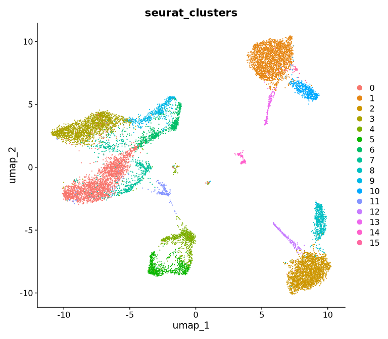

```r
DimPlot(original_data, group.by = "seurat_clusters")
```

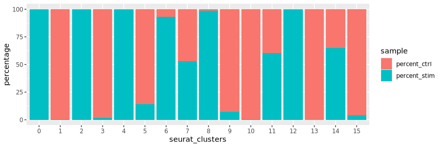

```r
original_data[[]] %>%
  group_by(seurat_clusters,stim) %>%
  count() %>%
  pivot_wider(
    names_from=stim,
    values_from=n,
    values_fill = 0
  ) %>%
  mutate(
    percent_stim=100*STIM/(STIM+CTRL),
    percent_ctrl=100*CTRL/(STIM+CTRL),
  ) %>%
  select(seurat_clusters,starts_with("percent")) %>%
  pivot_longer(
    cols=-seurat_clusters,
    names_to="sample",
    values_to="percentage"
  ) %>%
  ggplot(aes(x=seurat_clusters, y=percentage, fill=sample)) +
  geom_col()
```

The majority of the clusters are heavily biased towards one sample or the other, which is not what we’d want for an integrated analysis.

# Detection of integration anchors

To find integration anchors we need to split the full Seurat object into the original samples, we can then use the `FindIntegrationAnchors` function to identify the points of commonality between the samples.

```r
original_data %>%
  SplitObject(split.by = "stim") -> split_objects

split_objects
```

```
#> $CTRL
#> An object of class Seurat
#> 14053 features across 6548 samples within 1 assay
#> Active assay: RNA (14053 features, 2000 variable features)
#>  3 layers present: counts, data, scale.data
#>  2 dimensional reductions calculated: pca, umap
#>
#> $STIM
#> An object of class Seurat
#> 14053 features across 7451 samples within 1 assay
#> Active assay: RNA (14053 features, 2000 variable features)
#>  3 layers present: counts, data, scale.data
#>  2 dimensional reductions calculated: pca, umap
```

```r
FindIntegrationAnchors(split_objects) -> default_anchors
```

```
#> Computing 2000 integration features
#> Scaling features for provided objects
#> Finding all pairwise anchors
#> Running CCA
#> Merging objects
#> Finding neighborhoods
#> Finding anchors
#>  Found 16411 anchors
#> Filtering anchors
#>  Retained 7012 anchors
```

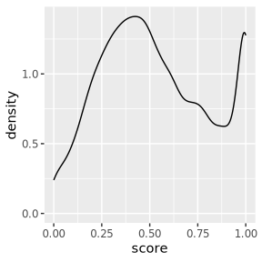

```r
default_anchors@anchors %>%
  ggplot(aes(x=score)) +
  geom_density()
```

Now we can convert the anchors into x,y coordinates within our UMAP reduction

```r
get_positions_for_anchors(default_anchors, reduction = "umap") -> default_anchor_positions

head(default_anchor_positions)
```

```
#> # A tibble: 6 × 12
#>   cell1 cell2 score dataset1 dataset2 cellid1        cellid2 cellid1_x cellid1_y
#>   <dbl> <dbl> <dbl>    <int>    <int> <chr>          <chr>       <dbl>     <dbl>
#> 1     1  2863 0.514        1        2 AAACATACATTTC… CCAGTC…      6.43      7.46
#> 2     1   279 0.4          1        2 AAACATACATTTC… AAGAAT…      6.43      7.46
#> 3     2  5838 0.886        1        2 AAACATACCAGAA… TACAAT…      4.16      9.19
#> 4     2  6920 0.914        1        2 AAACATACCAGAA… TGGAGA…      4.16      9.19
#> 5     2  4760 1            1        2 AAACATACCAGAA… GCGAGA…      4.16      9.19
#> 6     2  2492 1            1        2 AAACATACCAGAA… CAGACT…      4.16      9.19
#> # ℹ 3 more variables: cellid2_x <dbl>, cellid2_y <dbl>, anchor_weight <dbl>
```

You can see that we have both the CellIDs for the two datasets and the x,y positions in the chosen reduction.

We can now plot these out on the combined UMAP

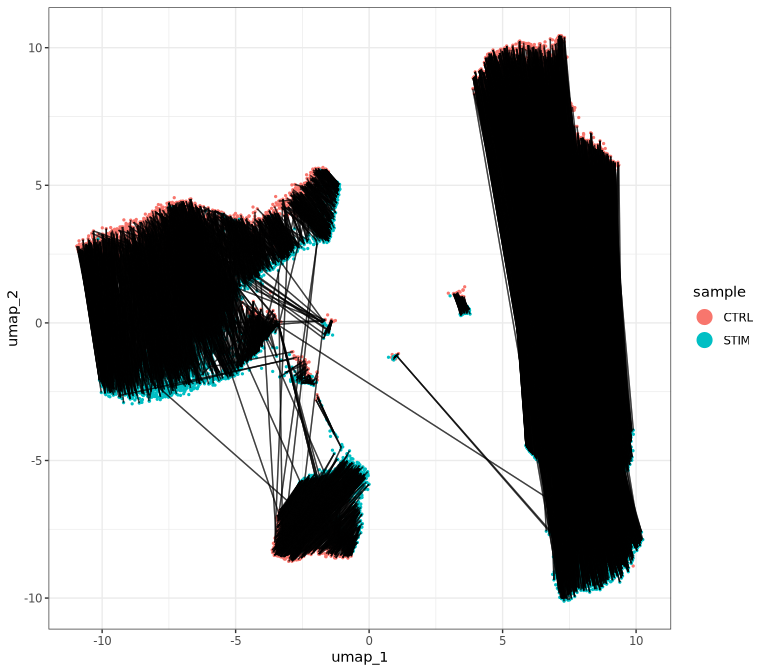

```r
plot_integration_anchors(
  split_objects,
  default_anchor_positions,
  reduction="umap"
) + theme_bw()
```

This is good but is overcrowded. We can randomly subsample to show fewer anchors

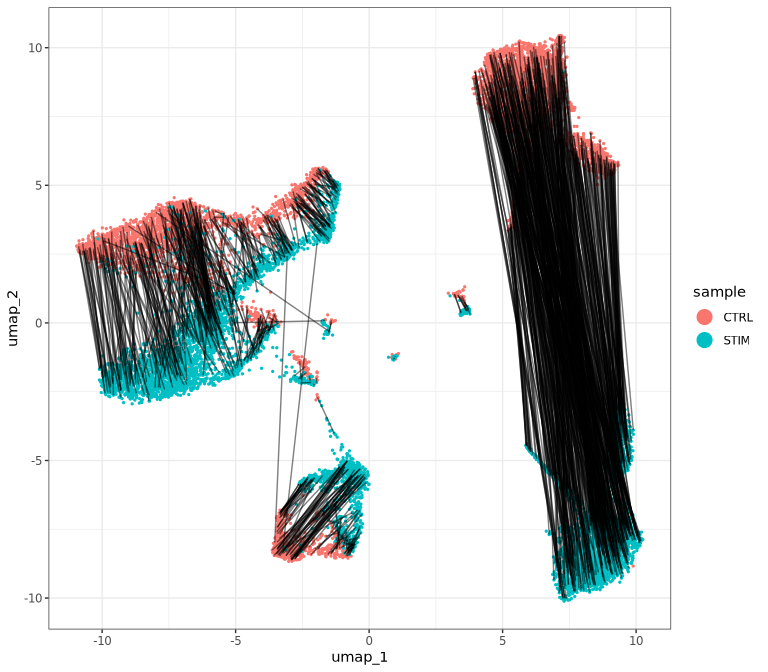

```r
plot_integration_anchors(
  split_objects,
  default_anchor_positions %>% sample_n(1000),
  reduction="umap"
) + theme_bw()
```

That’s a lot clearer and is one solution to the problem. Because we have a lot of anchors running in the same direction though we can group them together to simplify the plot.

```r
cluster_anchor_positions(default_anchor_positions, cluster_threshold = 3) -> clustered_default_anchor_positions
```

Now we can plot the clustered anchors. Their weight represents the number of individual anchors which were combined so we can filter on this to clean up the plot from sets with low weights.

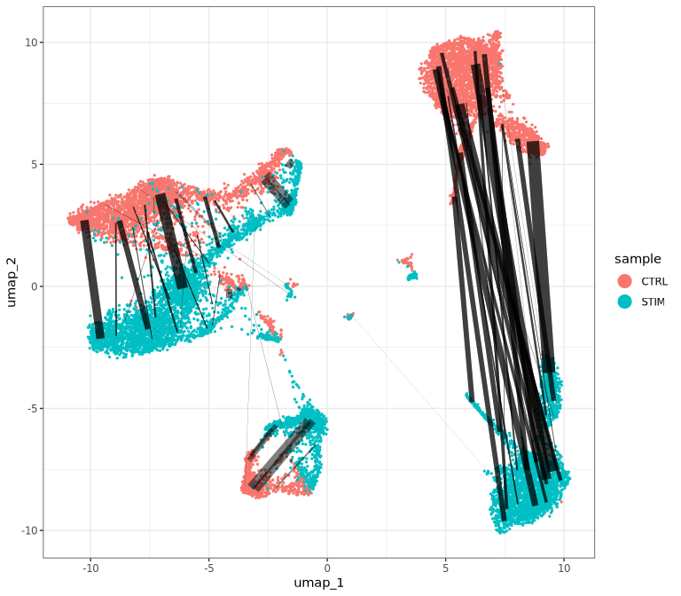

```r
plot_integration_anchors(
  split_objects,
  clustered_default_anchor_positions,
  reduction="umap",
) + theme_bw()
```

This is pretty nice but we an see some spurious links from clusters with large cell numbers and poor linkage to other secondary regions.

We can even remove some of the poorly clustered groups to reduce the noise further.

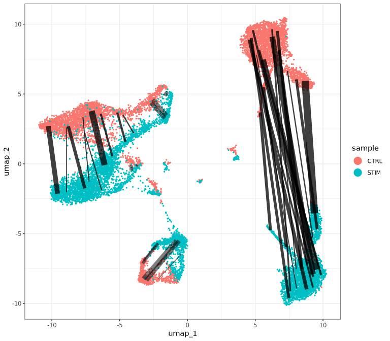

```r
plot_integration_anchors(
  split_objects,
  clustered_default_anchor_positions %>% filter(anchor_weight>50),
  reduction="umap",
) + theme_bw()
```

This shows a much clearer view of where the most frequent anchors are constructed and where the data is likely to skew when integration is finally performed.

You can play around with the degree of clustering and filtering to get the view you prefer.

# Matching Clusters

Another potentially useful approach is to take clusters defined in each of the individual datasets and then use the integration anchors to match up the links between clusters. This can be useful when transferring cell types for example.

## Find clusters in individual datasets

```r
split_objects[[1]] %>%
  FindNeighbors() %>%
  FindClusters(resolution = 0.2) -> split_objects[[1]]
```

```
#> Modularity Optimizer version 1.3.0 by Ludo Waltman and Nees Jan van Eck
#>
#> Number of nodes: 6548
#> Number of edges: 220665
#>
#> Running Louvain algorithm...
#> Maximum modularity in 10 random starts: 0.9423
#> Number of communities: 9
#> Elapsed time: 1 seconds
```

```r
split_objects[[2]] %>%
  FindNeighbors() %>%
  FindClusters(resolution = 0.2) -> split_objects[[2]]
```

```
#> Modularity Optimizer version 1.3.0 by Ludo Waltman and Nees Jan van Eck
#>
#> Number of nodes: 7451
#> Number of edges: 250428
#>
#> Running Louvain algorithm...
#> Maximum modularity in 10 random starts: 0.9438
#> Number of communities: 9
#> Elapsed time: 1 seconds
```

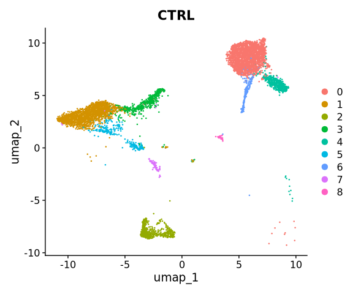

```r
DimPlot(split_objects[[1]], reduction="umap", group.by = "seurat_clusters") + ggtitle(split_objects[[1]][[]]$stim[[1]])
```

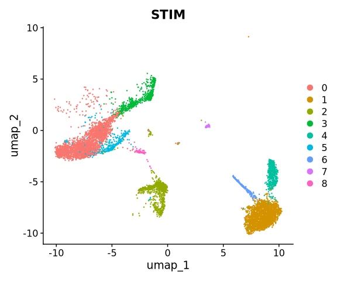

```r
DimPlot(split_objects[[2]], reduction="umap", group.by = "seurat_clusters") + ggtitle(split_objects[[2]][[]]$stim[[1]])
```

Now we can find integration anchors again

```r
FindIntegrationAnchors(split_objects) -> clustered_anchors
```

```
#> Computing 2000 integration features
#> Scaling features for provided objects
#> Finding all pairwise anchors
#> Running CCA
#> Merging objects
#> Finding neighborhoods
#> Finding anchors
#>  Found 16411 anchors
#> Filtering anchors
#>  Retained 7012 anchors
```

Now we can plot the anchors from this in a couple of ways.

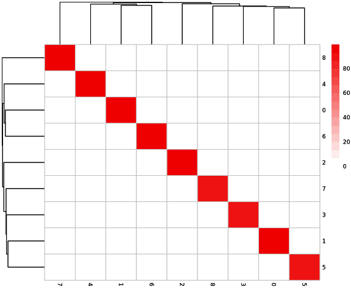

```r
plot_cluster_interaction_matrix(clustered_anchors,clusters1 = "seurat_clusters", clusters2 = "seurat_clusters")
```

We can also plot this on a dimension reduction plot.

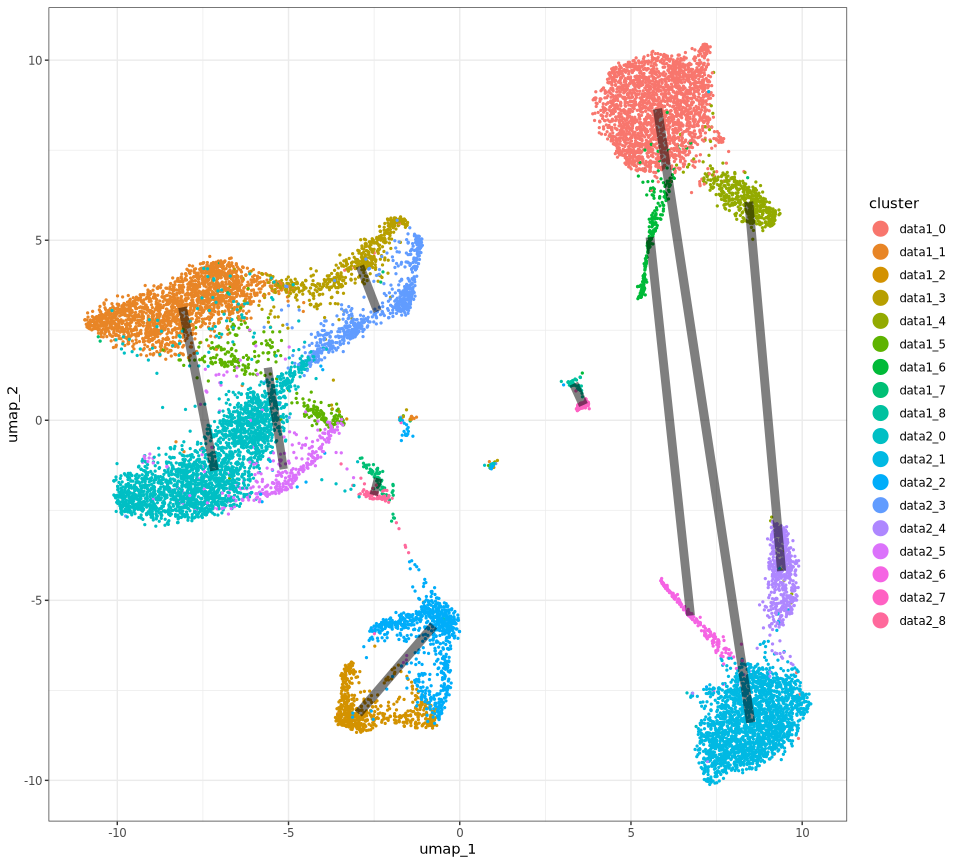

```r
dimplot_cluster_interactions(clustered_anchors,clusters1 = "seurat_clusters", clusters2 = "seurat_clusters", reduction="umap") +theme_bw()
```